# Reproducible Research: Analysis of US Severe Weather Impact to Public Health and Economic Problems

## Data Processing

### Load library

Load the library need for making plots first. Below code chunk was set to supress the output when loading libraries. “ggplot2” will be used to make plots in this report.

```r
library(ggplot2)
```

### Download and read data, cache if needed

Download the file and read it. “bzfile()” is used here to avoid the unzip process. Cache option is used here to make the code running faster after initial run.

```r
fileUrl <- "https://d396qusza40orc.cloudfront.net/repdata%2Fdata%2FStormData.csv.bz2"
download.file(fileUrl, destfile = "./repdata-data-StormData.csv.bz2", method = "curl")
storm <- read.csv(bzfile("./repdata-data-StormData.csv.bz2"), header = T, stringsAsFactors = F)
```

### Clean the data

This report focuses on the analysis of weather events impacting public health and economic, hence, the next step is to cleaning the data. The strategy is to choose the data of which either FATALITIES, INJURIES, PROPDMG OR CROPDMG is greater than 0.

```r
isFat <- storm$FATALITIES > 0
isInj <- storm$INJURIES > 0
isPro <- storm$PROPDMG > 0
isCro <- storm$CROPDMG > 0
intData <- storm[isFat | isInj | isPro | isCro, ]
```

According to the storm data documentation. The PRODDMGEXP and CROPDMGEXP are supposed to have value of “K”, “M”, or “B” to signify magnitude of number with meaning of thousands, millions or billions. So next step is to filter out those data with characters other than “K”, “M” or “B” in PRODDMGEXP or CROPDMGEXP columns. Let’s take a look at the composition of these two columns first.

```r
table(intData$PROPDMGEXP)
```

```
##
##             -      +      0      2      3      4      5      6      7
##  11585      1      5    210      1      1      4     18      3      3
##      B      h      H      K      m      M
##     40      1      6 231428      7  11320
```

```r
table(intData$CROPDMGEXP)
```

```
##
##             ?      0      B      k      K      m      M
## 152664      6     17      7     21  99932      1   1985
```

Then filter the data by the criteria described previously.

```r
isVal <- intData$PROPDMGEXP %in% c("k", "K", "m", "M", "b", "B") | intData$CROPDMGEXP %in% c("k", "K", "m", "M", "b", "B")
intData <- intData[isVal, ]
nrow(intData)
```

[output not shown]

The number of valid data for this report is 247088.

## Analyze Data

In the clean data set derived from previous part, the data of damage are represented in four columns (PROPDMG, PROPDMGEXP, CROPDMG, CROPDMGEXP) and the impact of public health are represented in two columns (FATALITIES, INJURIES). They are not ready for direct comparison and computation, especially the cost of the damage are in thousands, millions or billions dollars. Below code chunk will add another two new columns named COST and HEALTH.

```r
isPK <- intData$PROPDMGEXP %in% c("k", "K")
isPM <- intData$PROPDMGEXP %in% c("m", "M")
isPB <- intData$PROPDMGEXP %in% c("b", "B")
isCK <- intData$CROPDMGEXP %in% c("k", "K")
isCM <- intData$CROPDMGEXP %in% c("m", "M")
isCB <- intData$CROPDMGEXP %in% c("b", "B")
intData$COST <- intData$PROPDMG * (1e3 * isPK + 1e6 * isPM + 1e9 * isPB)
intData$COST <- intData$COST + intData$CROPDMG * (1e3 * isCK + 1e6 * isCM + 1e9 * isCB)
intData$HEALTH <- intData$FATALITIES + intData$INJURIES
```

The data set has 426 unique types of events. Many of them are actually the same type of event. The code chunk below will categorize and standardize them.

```r
intData$EVTYPE[grep("Flood|Dam Break|RIP Current|Astronomical|Stream|Urban small", intData$EVTYPE, ignore.case = T)] <- "Flood"
intData$EVTYPE[grep("Tornado|Torndao|Funnel Cloud|Waterspout|Landspout", intData$EVTYPE, ignore.case = T)] <- "Tornado"
intData$EVTYPE[grep("Snow|Blizzard", intData$EVTYPE, ignore.case = T)] <- "Snow"
intData$EVTYPE[grep("Hail|Ice Storm", intData$EVTYPE, ignore.case = T)] <- "Hail"
intData$EVTYPE[grep("Erosion", intData$EVTYPE, ignore.case = T)] <- "Erosion"
intData$EVTYPE[grep("Marine|Surf|Wave|Swell|Tide|Coastal|Storm Surge|High Water|Seiche", intData$EVTYPE, ignore.case = T)] <- "Wave"
intData$EVTYPE[grep("Wind|TSTM|Turbulence|Gustnado|Apache", intData$EVTYPE, ignore.case = T)] <- "Wind"
intData$EVTYPE[grep("Dust", intData$EVTYPE, ignore.case = T)] <- "Dust"
intData$EVTYPE[grep("Rain|Precipitation|Shower|Urban and small", intData$EVTYPE, ignore.case = T)] <- "Rain"
intData$EVTYPE[grep("Storm", intData$EVTYPE, ignore.case = T)] <- "Storm"
intData$EVTYPE[grep("Fire", intData$EVTYPE, ignore.case = T)] <- "Fire"
intData$EVTYPE[grep("Frost", intData$EVTYPE, ignore.case = T)] <- "Frost"
intData$EVTYPE[grep("Heat|Warm", intData$EVTYPE, ignore.case = T)] <- "Heat"
intData$EVTYPE[grep("Cold", intData$EVTYPE, ignore.case = T)] <- "Cold"
intData$EVTYPE[grep("Wet", intData$EVTYPE, ignore.case = T)] <- "Wet"
intData$EVTYPE[grep("Drought", intData$EVTYPE, ignore.case = T)] <- "Drought"
intData$EVTYPE[grep("Fog", intData$EVTYPE, ignore.case = T)] <- "Fog"
intData$EVTYPE[grep("Freeze|Freezing", intData$EVTYPE, ignore.case = T)] <- "Freeze"
intData$EVTYPE[grep("Hurricane", intData$EVTYPE, ignore.case = T)] <- "Hurricane"
intData$EVTYPE[grep("Ice|Icy|Glaze", intData$EVTYPE, ignore.case = T)] <- "Ice"
intData$EVTYPE[grep("Typhoon|Depression", intData$EVTYPE, ignore.case = T)] <- "Typhoon"
intData$EVTYPE[grep("Waterspout", intData$EVTYPE, ignore.case = T)] <- "Waterspout"
intData$EVTYPE[grep("Winter|Wintry", intData$EVTYPE, ignore.case = T)] <- "Winter"
intData$EVTYPE[grep("Smoke|Ash", intData$EVTYPE, ignore.case = T)] <- "Smoke"
intData$EVTYPE[grep("Ligntning|Lightning|Lighting", intData$EVTYPE, ignore.case = T)] <- "Lightning"
intData$EVTYPE[grep("Mud", intData$EVTYPE, ignore.case = T)] <- "Mudslide"
intData$EVTYPE[grep("Burst", intData$EVTYPE, ignore.case = T)] <- "Burst"
intData$EVTYPE[grep("Landslide", intData$EVTYPE, ignore.case = T)] <- "Landslide"
intData$EVTYPE[grep("\\?|other", intData$EVTYPE, ignore.case = T)] <- "Other"
```

```r
table(intData$EVTYPE)[order(table(intData$EVTYPE))]
```

```
##
##  Landslump ROCK SLIDE    Erosion  HIGH SEAS      Smoke        Wet
##          1          1          2          2          3          5
##  HEAVY MIX   Mudslide    TSUNAMI      Other     Freeze    Typhoon
##          8          9         14         34         36         44
##        Ice      Burst       Cold      Frost        Fog  AVALANCHE
##         54         74        118        126        138        144
##       Dust  Landslide  Hurricane    Drought       Heat     Winter
##        168        193        210        266        285        527
##       Wave       Fire       Rain      Storm       Snow  Lightning
##        605       1156       1156       1845       2019      10978
##       Hail      Flood    Tornado       Wind
##      27173      33064      39882     126748
```

## Results

Aggregate the data set by the event type and then apply the sum function to get 2 new data sets named “health” and “economic”. The final plots will be based on these 2 new data sets.

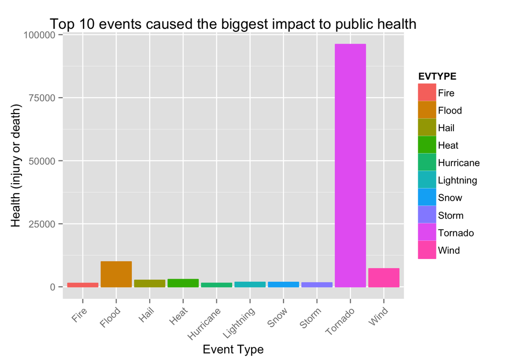

```r
health <- aggregate(HEALTH ~ EVTYPE, data = intData, FUN = sum)
health <- health[order(health$HEALTH, decreasing = T), ][1:10,]
economic <- aggregate(COST ~ EVTYPE, data = intData, FUN = sum)
economic <- economic[order(economic$COST, decreasing = T), ][1:10,]
ggplot(data = health, aes(x = EVTYPE, y = HEALTH, colour = EVTYPE)) + geom_bar(aes(fill = EVTYPE),stat="identity") + xlab("Event Type") + ylab("Health (injury or death)") + theme(axis.text.x = element_text(angle = 45, hjust = 1, vjust = 1)) + ggtitle("Top 10 events caused the biggest impact to public health")
```

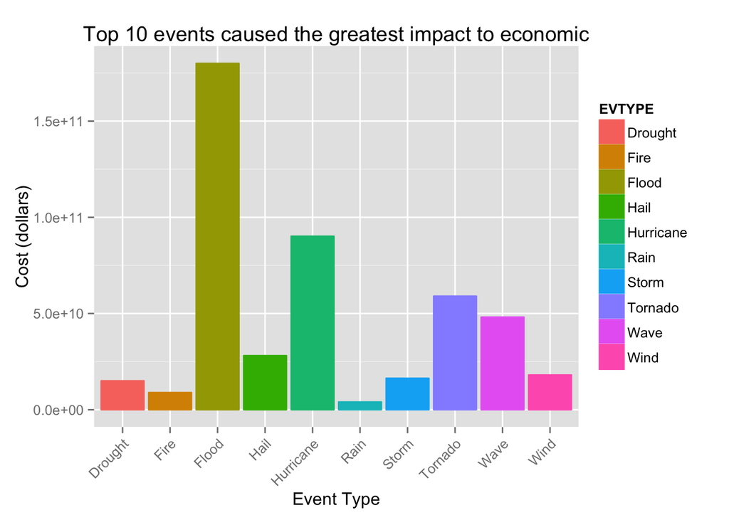

```r
ggplot(data = economic, aes(x = EVTYPE, y = COST, colour = EVTYPE)) + geom_bar(aes(fill = EVTYPE),stat="identity") + xlab("Event Type") + ylab("Cost (dollars)") + theme(axis.text.x = element_text(angle = 45, hjust = 1, vjust = 1)) + ggtitle("Top 10 events caused the greatest impact to economic")
```

From the above two plots, TORNADO, FLOOD and WIND are the events which caused the biggest number of injuries or death. FLOOD, HURRICANE and TORNADO are the events that caused the greatest impact to economic.